# BREADTH FIRST SEARCH - DESCRIPTION

## BREADTH FIRST SEARCH

### INTRODUCTION

- Breadth-first search is a recursive graph traversal algorithm that starts traversing the graph from the root node and explores all the neighboring nodes.
- Then, it selects the nearest node and explores all the unexplored nodes.
- BFS puts every vertex of the graph into two categories - visited non-visited.
- Below is an example of how breadth first search works - starting node is A, ending node is G.

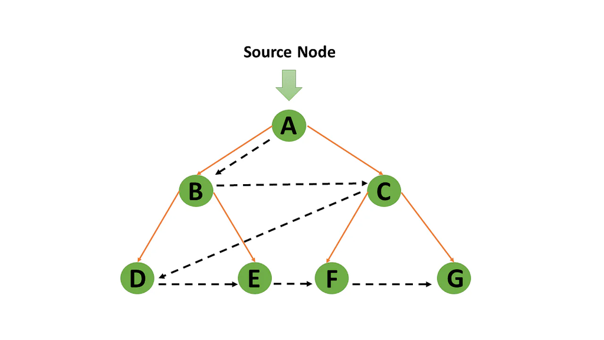

### ALGORITHM

- STEP 1 - Start with the source node.
- STEP 2 - Add that node at the front of the queue to the visited list.
- STEP 3 - Make a list of the nodes as visited that are close to that vertex.
- STEP 4 - Dequeue the nodes once they are visited.
- STEP 5 - Repeat the actions until the queue is empty.
- STEP 6 - Stop.

## CASE - 1

### STARTING NODE - S, ENDING NODE - F

- The traversal starts at node S (level 0) and ends with node F.
- The first level is searched (i.e.,) S to A, B, C.
- Then the second level is searched (i.e.,) C to D, H, L.
- It is followed by the third level (i.e.,) L to F.
- The goal node is reached, so the search stops.
- It follows the following route to reach the goal node(F) from the starting node(S):

  ```
                            S -> A -> B -> C -> D -> H -> L -> F
  ```

## CASE - 2

### STARTING NODE - S, ENDING NODE - E

- The traversal starts at node S (level 0) and ends with node E.
- The first level is searched (i.e.,) S to A, B, C.
- Then the second level is searched (i.e.,) C to D, H, L.
- It is followed by the third level (i.e.,) L to F, G, I, J.
- It is followed by the fourth level (i.e.,) J to E and since the goal node is reached, the search stops.
- It follows the following route to reach the goal node(E) from the starting node(S):

  ```
                            S -> A -> B -> C -> D -> H -> L -> F -> G -> I -> J -> E
  ```